# Data Visualization Tutorial

Robin Donatello

Last Updated 08-12-2017

# Introduction

Visualizing your data is hands down the most important thing you can learn to do. There are links to additional resources at the end of this document for additional learning.

There are two audiences in mind when creating data visualizations:

1. For your eyes only (FYEO). These are quick and dirty plots, without annotation. Meant to be looked at once or twice.
2. To share with others. These need to completely stand on their own. Axes labels, titles, colors as needed, possibly captions.

You will see, and slowly learn, how to add these annotations and how to clean up your graphics to make them sharable. `ggplot2` already does a lot of this work for you.

We will also use the two most common methods used to create plots. 1) Base graphics, 2) the `ggplot2` package. Each have their own advantages and disadvantges. If you have not done so already, go ahead and install the `ggplot2` package now.

For **almost** every plot discussed we will create two types of plots

1. FYEO - using base graphics. (Base == Comes with R) Very powerful, but can be technical.
2. FYEO - using `ggplot2`. Each have their own advantages and disadvantges.

As time permits I will update each section with a third type of plot -

3. Sharable - Contains all bells and whistles needed to make it presentable to others.

Your task, should you choose to accept, is to follow along through this tutorial and at each step try to reproduce the plot shown. You can accomplish this by simply copying and pasting the syntax into a new R code (or R Markdown) document.

## The syntax of `ggplot`

The reason we use the functions in `ggplot2` is for consistency in the structure of it’s arguments. Here is a bare bones generic plotting function:

```r
ggplot(data, aes(x=x, y=y, col=col, fill=fill, group=group)) +  geom_THING()
```

### Required arguments

- `data`: What data set is this plot using? This is ALWAYS the first argument.
- `aes()`: This is the *aestetics* of the plot. What’s varible is on the x, what is on the y? Do you want to color by another variable, perhaps fill some box by the value of another variable, or group by a variable.
- `geom_THING()`: Every plot has to have a geometry. What is the shape of the thing you want to plot? Do you want to plot points - use `geom_points()`. Want to connect those points with a line? Use `geom_lines()`. We will see many varieties in this lab.

### Optional but helpful arguments

- `ggtitle`: This is the overall plot title
- `xlab()` and `ylab()` axis titles.
- scale_xy_blah to extend limits
- scale_fill_blah to specifying a fixed color, and change auto legend title
- themes

For a **full** , and comprehensive tutorial and reference guide on how to do nearly anything in ggplot – this is by far my favorite reference http://www.cookbook-r.com/Graphs/ I reference things in there (like how to remove or change the title of a legend) constantly.

## The Data

We will use a subset of the `diamonds` dataset that comes with the `ggplot2` package. This dataset contains the prices and other attributes of almost 54,000 diamonds. Review `?diamonds` to learn about the variables we will be using.

```r
data("diamonds")
set.seed(1410) # Make the sample reproducible
dsmall <- diamonds[sample(nrow(diamonds), 1000), ]
```

# Univariate (Single Variable)

## Plot

The most basic plotting function is simply `plot()`. This function gives you a plot suitable for the data type you give it. Here `depth` is a continuous variable, so `plot()` returns a dotplot of the value of depth against the row number (index).

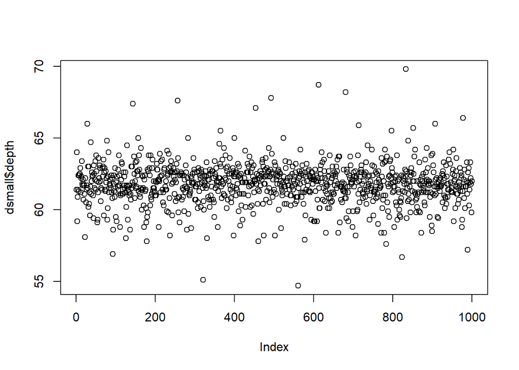

```r
plot(dsmall$depth)
```

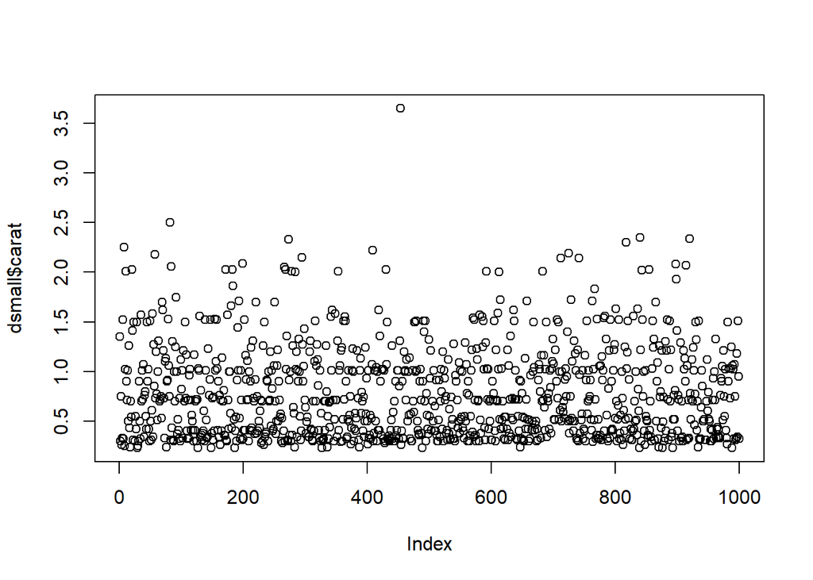

```r
plot(dsmall$carat)
```

## Categorical variables

Both Nominal and Ordinal data types can be visualized using the same methods: tables, barcharts and pie charts.

### Tables

Tables are the most common way to get summary statistics of a categorical variable. The `table()` function produces a frequency table, where each entry represents the number of records in the data set holding the corresponding labeled value.

```r
table(dsmall$cut)
```

```
##
##      Fair      Good Very Good   Premium     Ideal
##        27        83       226       277       387
```

There are 27 Fair quality diamonds, 83 good quality and 387 Ideal quality diamonds in this sample.

### Barcharts / Barplots

A Barchart or barplot takes these frequencies, and draws bars along the X-axis where the height of the bars is determined by the frequencies seen in the table.

#### base

To create a barplot/barchart in base graphics requires the data to be in summarized in a table form first. Then the result of the table is plotted. The first argument is the table to be plotted, the `main` argument controls the title.

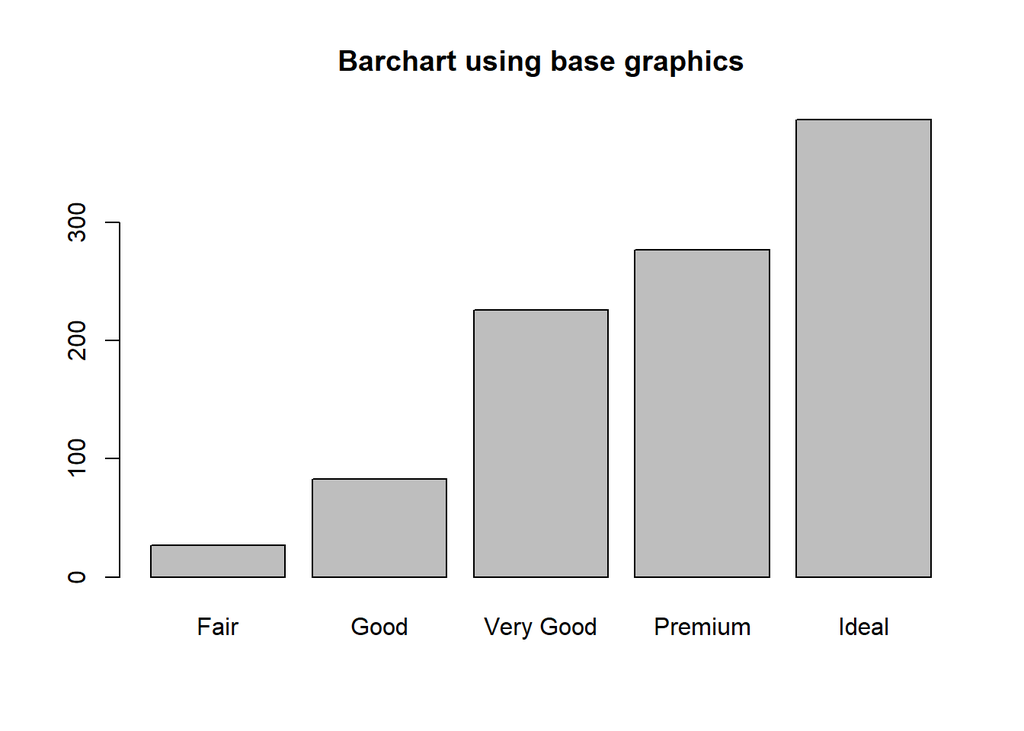

```r
dc <- table(dsmall$cut)
barplot(dc, main="Barchart using base graphics")
```

#### ggplot

The geometry needed to draw a barchart in ggplot is `geom_bar()`.

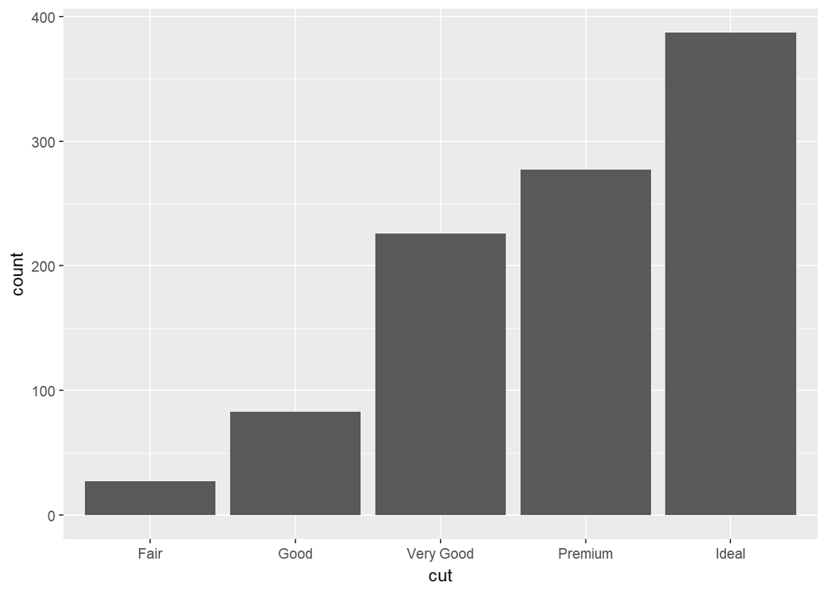

```r
ggplot(dsmall, aes(x=cut)) + geom_bar()
```

#### pretty

The biggest addition to a barchart is the numbers on top of the bars. This isn’t mandatory, but it does make it nice.

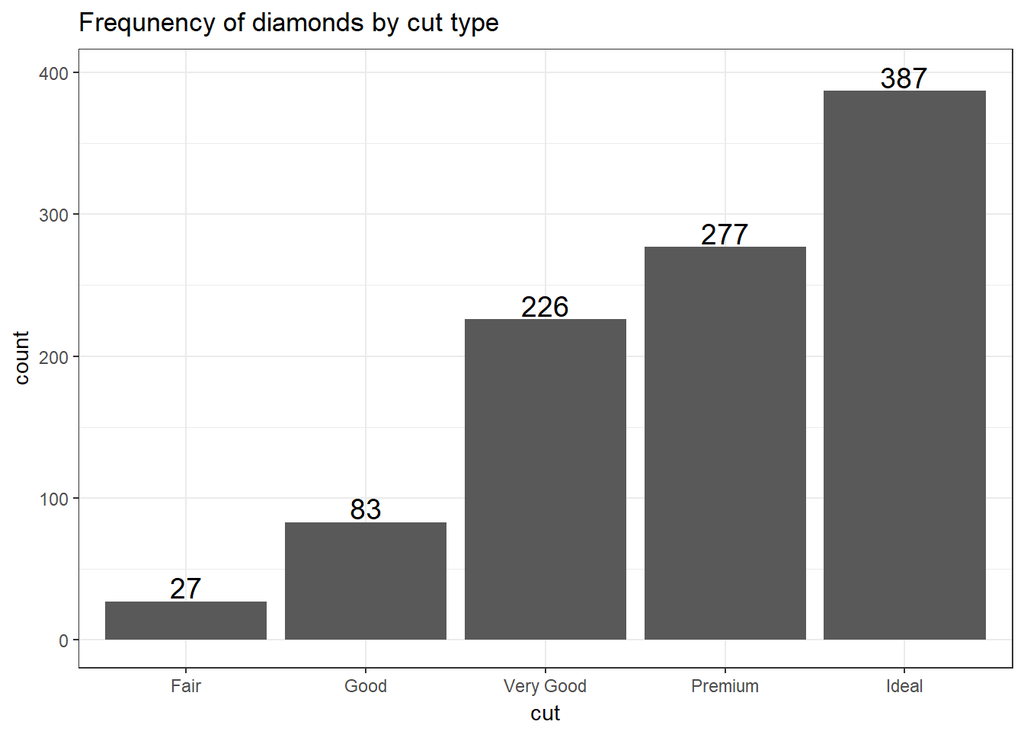

```r
ggplot(dsmall, aes(x=cut)) + theme_bw() +
    geom_bar(aes(y = ..count..)) + ggtitle("Frequnency of diamonds by cut type") +
    geom_text(aes(y=..count.. + 10, label=..count..), stat='count', size = 5)
```

#### Plotting Proportions

Often you don’t want to compare counts but percents. To accomplish this, we have to aggregate the data to calculate the proportions first, then plot the aggregated data using `geom_col` to create the columns.

```r
cut.props <- data.frame(prop.table(table(dsmall$cut)))
cut.props # what does this data look like?
```

```
##        Var1  Freq
## 1      Fair 0.027
## 2      Good 0.083
## 3 Very Good 0.226
## 4   Premium 0.277
## 5     Ideal 0.387
```

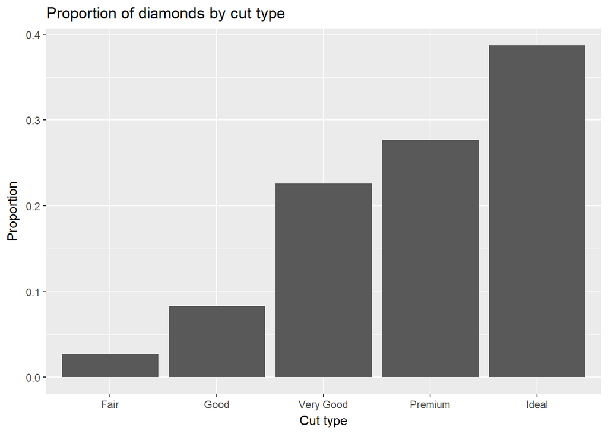

```r
ggplot(cut.props, aes(x=Var1, y=Freq)) + geom_col() +
  ylab("Proportion") + xlab("Cut type") +
  ggtitle("Proportion of diamonds by cut type")
```

### Cleveland Dot Plots

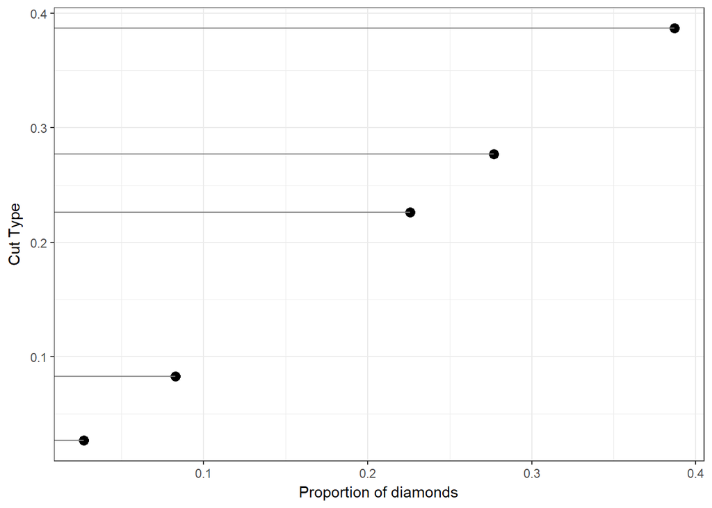

```r
ggplot(cut.props, aes(x=Freq, y=Freq)) +
  geom_point(size = 3) + xlab("Proportion of diamonds") +
  theme_bw() + ylab("Cut Type") +
  geom_segment(aes(yend=Freq), xend=0, color='grey50')
```

### Pie Chart

Pie charts are my *least* favorite plotting type. Human eyeballs can’t distinguish between angles as well as we can with heights. Just like `barplot()`, `pie()` takes a table object as it’s argument.

#### base

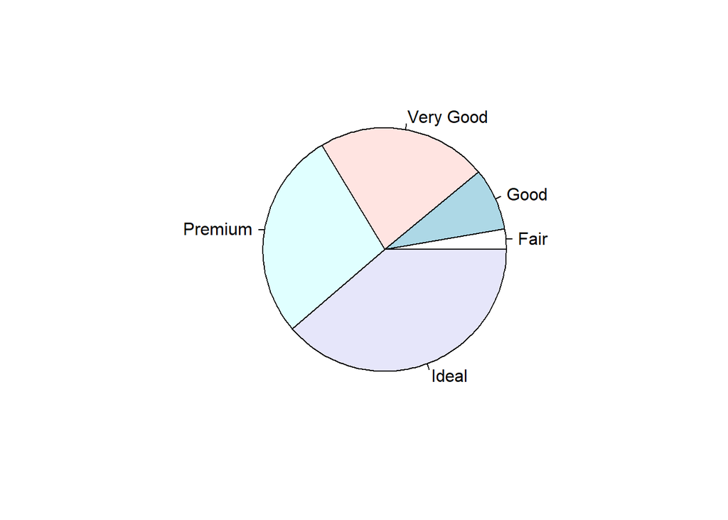

```r
dc <- table(dsmall$cut)
pie(dc)
```

There are ways to make a nice one using ggplot, but i’m more familiar with base graphics here. So that’s whatcha get. The primary piece needed is to add the percentages of each wedge.

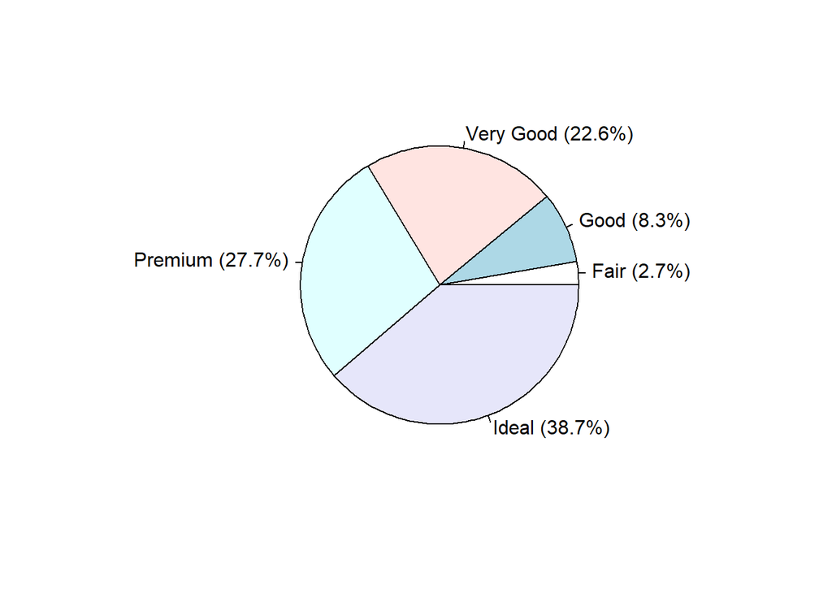

```r
pie(dc, labels = paste0(names(dc), ' (', prop.table(dc)*100, "%)"))
```

### Waffle Chart

This type of chart is not natively found in the `ggplot2` package, but it’s own `waffle` package. These are great for infographics.

Reference: https://www.r-bloggers.com/making-waffle-charts-in-r-with-the-new-waffle-package/

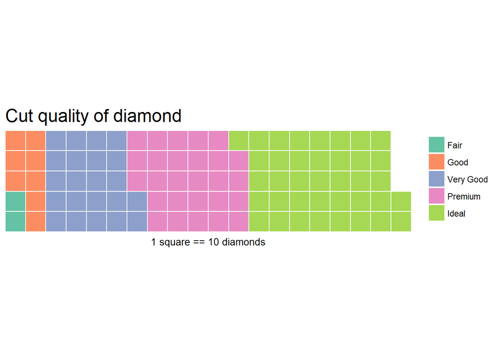

```r
library(waffle)

waffle(dc/10, rows=5, size=0.5,
       title="Cut quality of diamond",
       xlab="1 square == 10 diamonds")
```

## Continuous variable

Here we can look at the price, carat, and depth of the diamonds.

### Dotplot

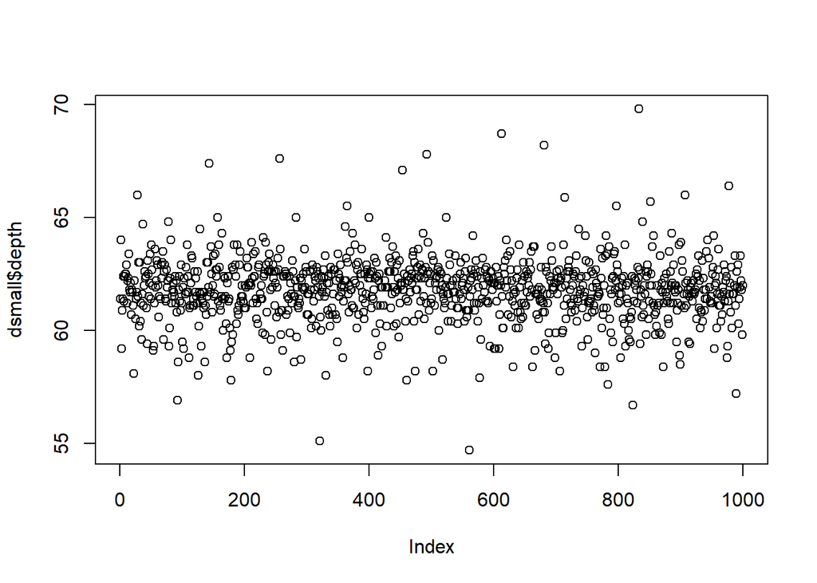

```r
plot(dsmall$depth)
```

The base function `plot()` creates a **dotplot** for a continuous variable. The value of the variable is plotted on the y axis, and the index, or row number, is plotted on the x axis. This gives you a nice, quick way to see the values of the data.

Often you are not interested in the individual values of each data point, but the *distribution* of the data. In other words, where is the majority of the data? Does it look symmetric around some central point? Around what values do the bulk of the data lie?

### Histograms

```r
table(cut(dsmall$depth, 7))
```

```
##
## (54.7,56.9]   (56.9,59]   (59,61.2] (61.2,63.3] (63.3,65.5] (65.5,67.6]
##           3          35         222         654          72          10
## (67.6,69.8]
##           4
```

In a histogram, the binned counts are plotted as bars into a histogram. Note that the x-axis is continuous, so the bars touch. This is unlike the barchart that has a categorical x-axis, and vertical bars that are separated.

#### base

You can make a histogram in base graphics super easy.

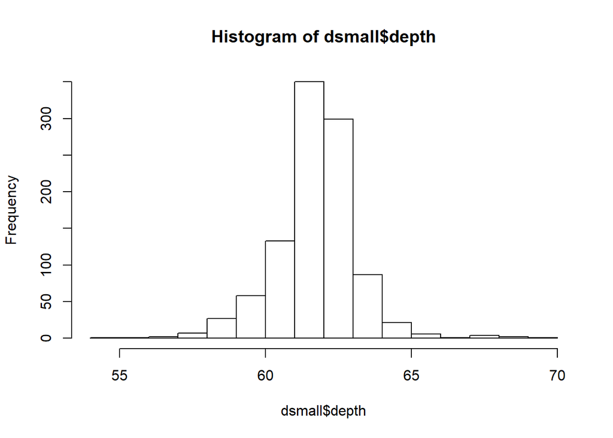

```r
hist(dsmall$depth)
```

And it doesn’t take too much to clean it up. Here you can specify the number of bins by specifying how many `breaks` should be made in the data (the number of breaks controls the number of bins, and bin width) and use `col` for the fill color.

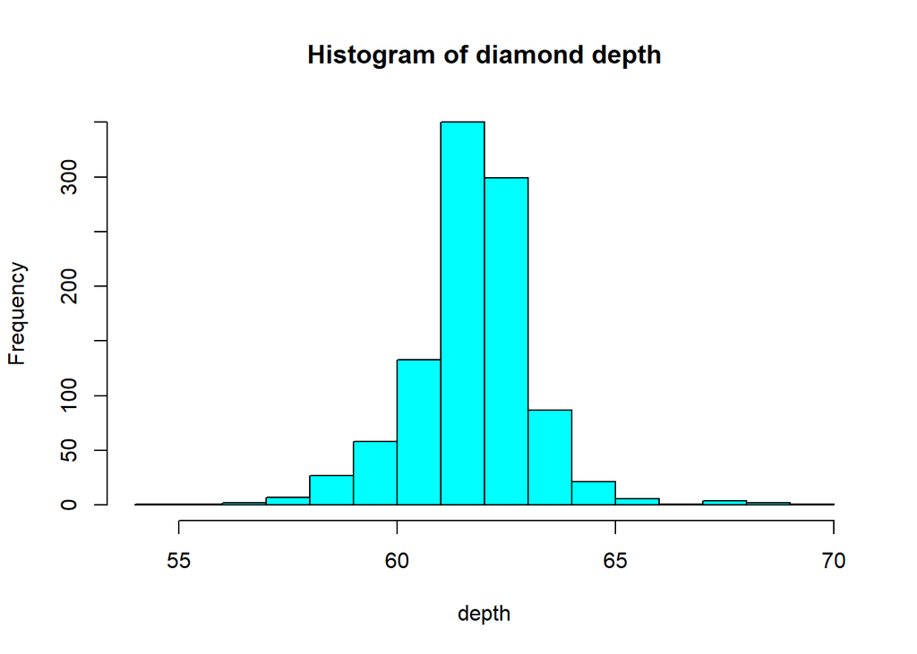

```r
hist(dsmall$depth, xlab="depth", main="Histogram of diamond depth", col="cyan", breaks=20)
```

#### ggplot

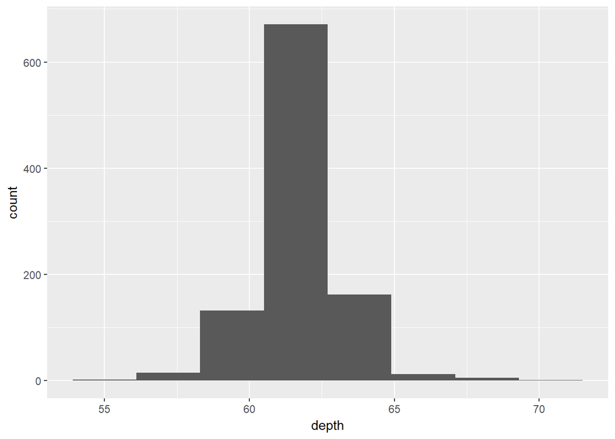

```r
ggplot(dsmall, aes(x=depth)) + geom_histogram(binwidth = 2.2)
```

The binwidth here is set by looking at the cut points above that were used to create 7 bins. Notice that darkgrey is the default fill color, but makes it hard to differentiate between the bars. So we’ll make the outline black using `colour`, and `fill` the bars with white.

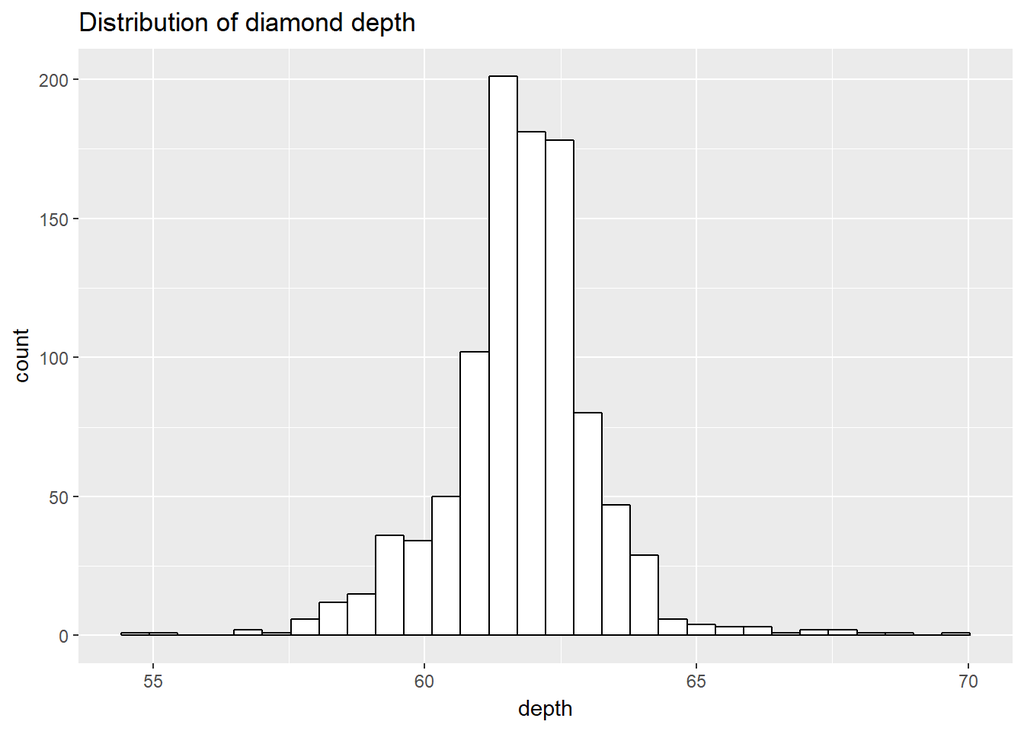

```r
ggplot(dsmall, aes(x=depth)) + geom_histogram(colour="black", fill="white") +
  ggtitle("Distribution of diamond depth")
```

Note I did **not** specify the `binwidth` argument here. The size of the bins can hide features from your graph, the default value for ggplot2 is range/30 and usually is a good choice.

### Density plots

To get a better idea of the true shape of the distribution we can “smooth” out the bins and create what’s called a `density` plot or curve. Notice that the shape of this distribution curve is much more… “wigglier” than the histogram may have implied.

#### graphics

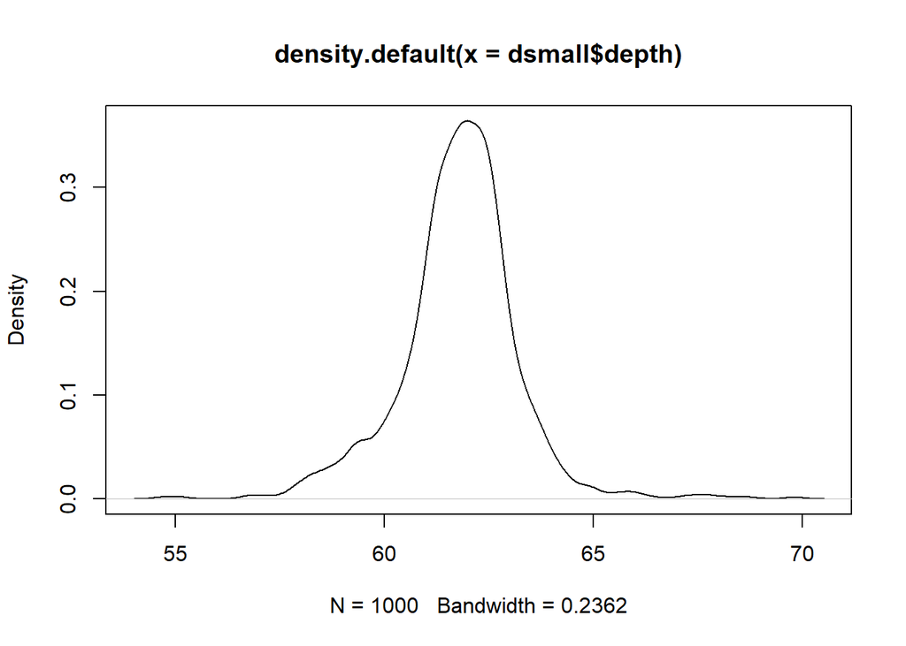

```r
plot(density(dsmall$depth))
```

Awesome title huh? (NOT)

#### ggplot2

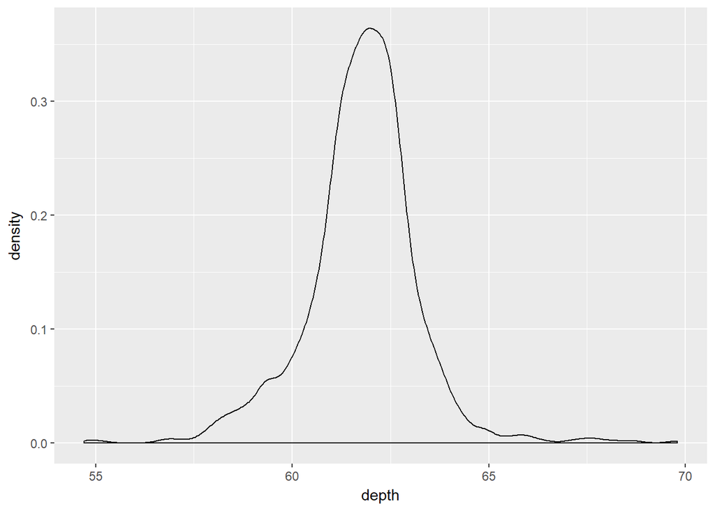

```r
ggplot(dsmall, aes(x=depth)) + geom_density()
```

### Histograms + density

Often is is more helpful to have the density (or kernal density) plot *on top of* a histogram plot.

#### Base

Since the height of the bars in a histogram default to showing the frequency of records in the data set within that bin, we need to 1) scale the height so that it’s a *relative frequency*, and then use the `lines()` function to add a `density()` line on top.

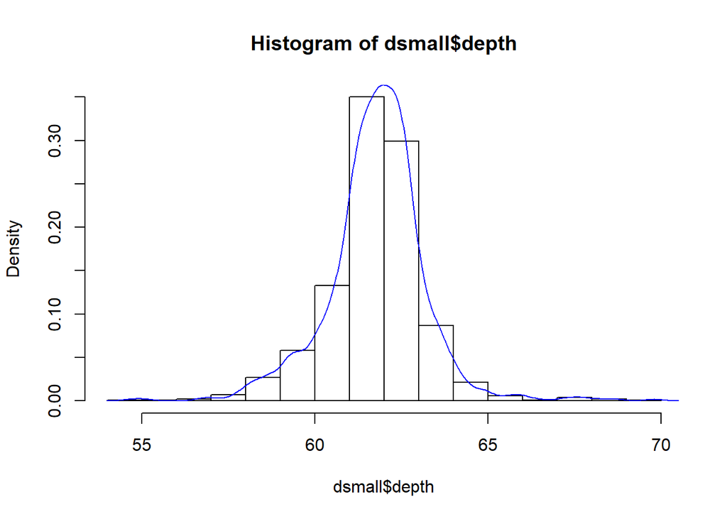

```r
hist(dsmall$depth, prob=TRUE)
lines(density(dsmall$depth), col="blue")
```

#### ggplot

The syntax starts the same, we’ll add a new geom, `geom_density` and color the line blue. Then we add the histogram geom using `geom_histogram` but must specify that the y axis should be on the density, not frequency, scale. Note that this has to go inside the aestetic statement `aes()`. I’m also going to get rid of the fill by using `NA` so it doesn’t plot over the density line.

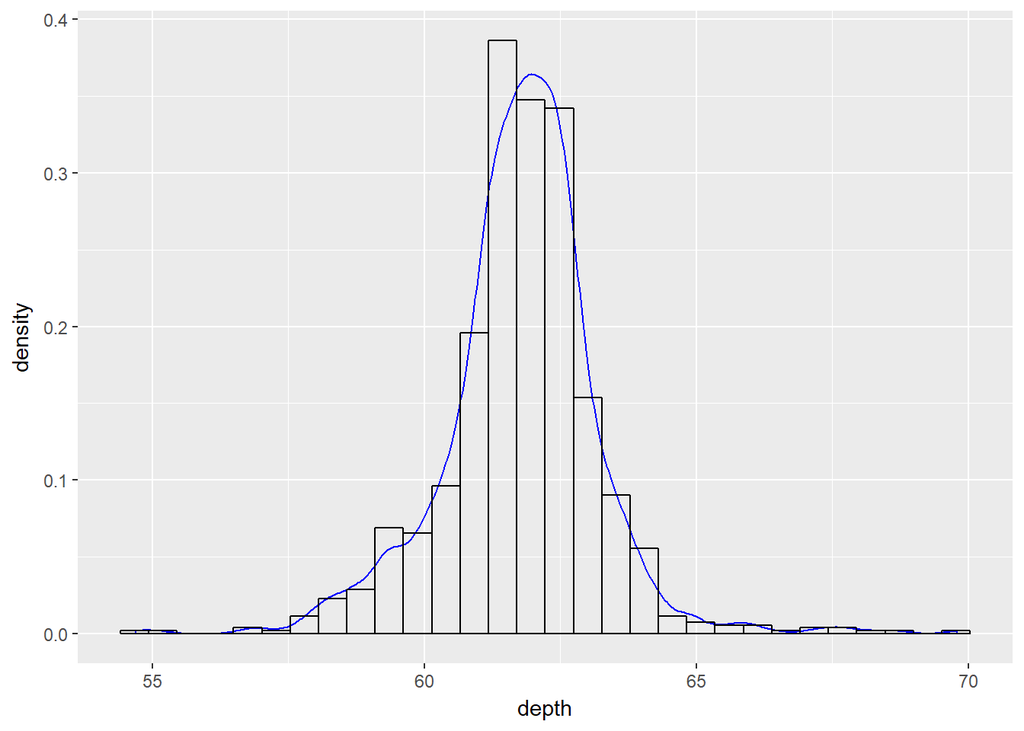

```r
ggplot(dsmall, aes(x=depth)) + geom_density(col="blue") +
  geom_histogram(aes(y=..density..), colour="black", fill=NA)
```

### Boxplots

Another very common way to visualize the distribution of a continuous variable is using a boxplot. Boxplots are useful for quickly identifying where the bulk of your data lie. R specifically draws a “modified” boxplot where values that are considered outliers are plotted as dots.

#### base

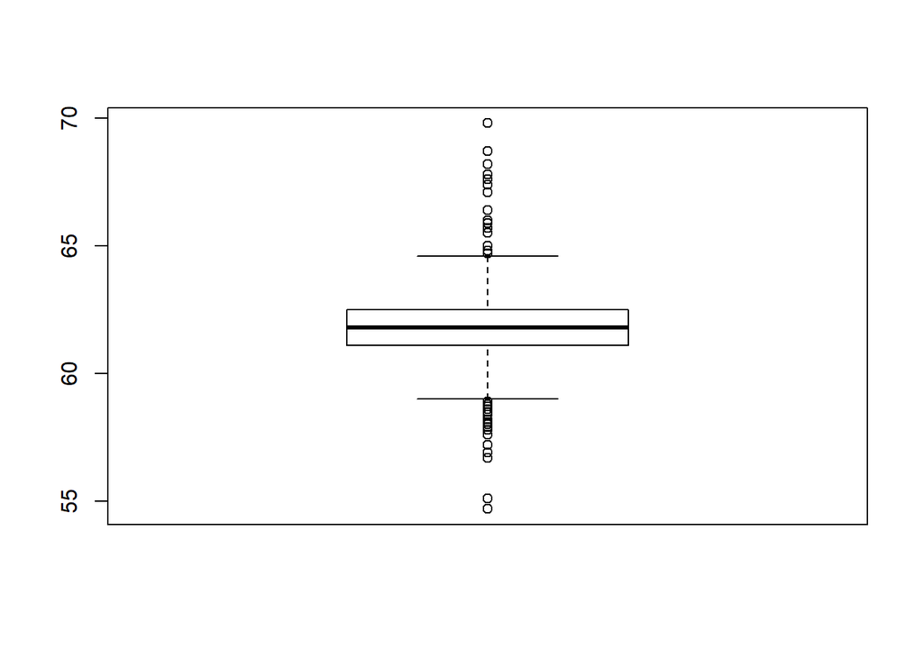

```r
boxplot(dsmall$depth)
```

Notice that the only axis labeled is the y=axis. Like a dotplot the x axis, or “width”, of the boxplot is meaningless here. We can make the axis more readable by flipping the plot on it’s side.

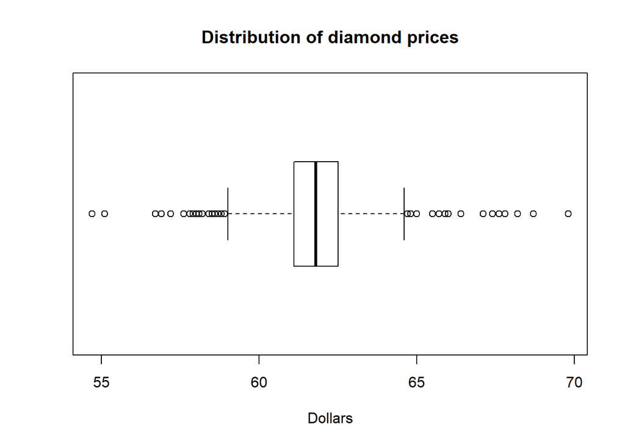

```r
boxplot(dsmall$depth, horizontal = TRUE, main="Distribution of diamond prices", xlab="Dollars")
```

Horizontal is a bit easier to read in my opinion.

#### ggplot

What about ggplot? ggplot doesn’t really like to do univariate boxplots. We can get around that by specifying that we want the box placed at a specific x value.

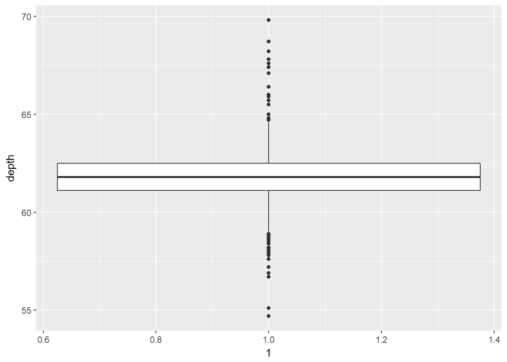

```r
ggplot(dsmall, aes(x=1, y=depth)) + geom_boxplot()
```

To flip it horizontal you may think to simply swap x and y? Good thinking. Of course it wouldn’t be that easy. So let’s just flip the whole darned plot on it’s coordinate axis.

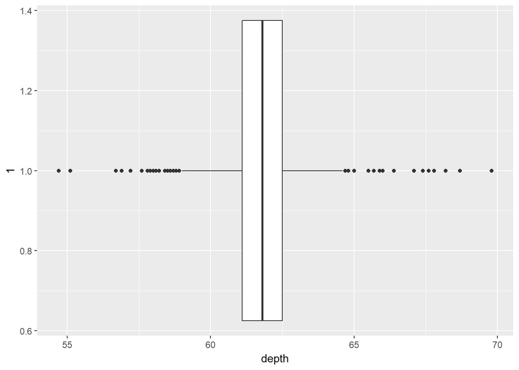

```r
ggplot(dsmall, aes(x=1, y=depth)) + geom_boxplot() + coord_flip()
```

### Violin plots

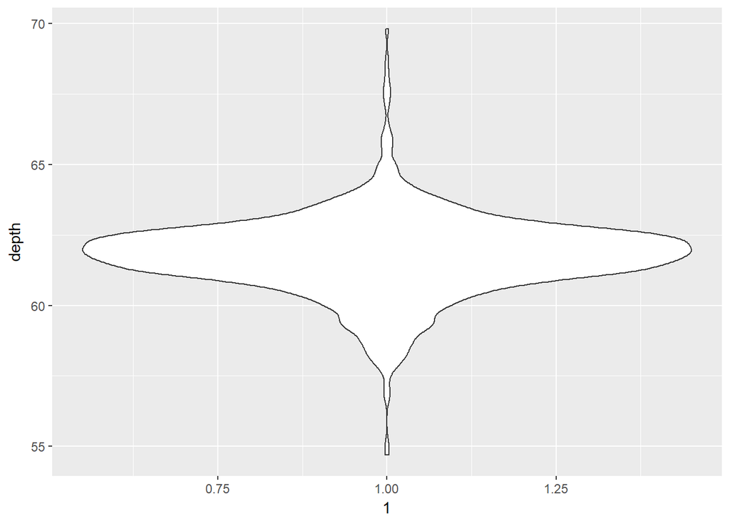

```r
ggplot(dsmall, aes(x=1, y=depth)) + geom_violin()
```

### Boxplot + Violin plots

Overlaying a boxplot and a violin plot serves a similar purpose to Histograms + Density plots.

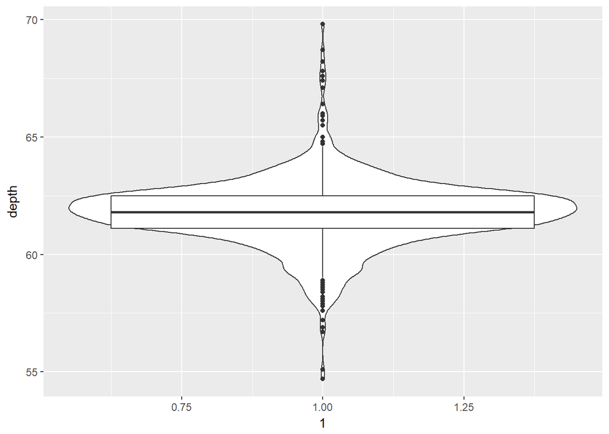

```r
ggplot(dsmall, aes(x=1, y=depth)) + geom_violin() + geom_boxplot()
```

Better appearance - different levels of transparency of the box and violin.

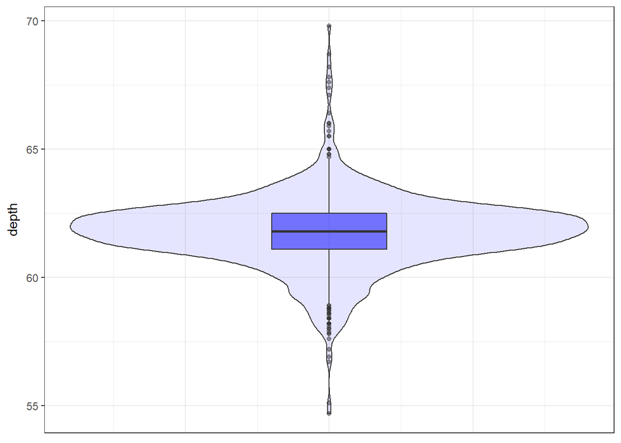

```r
ggplot(dsmall, aes(x=1, y=depth)) + xlab("") + theme_bw() +
              geom_violin(fill="blue", alpha=.1) +
              geom_boxplot(fill="blue", alpha=.5, width=.2) +
              theme(axis.title.x=element_blank(),
              axis.text.x=element_blank(),
              axis.ticks.x=element_blank())
```

## Normal QQ plots

The last useful plot that we will do on a single continuous variable is to assess the *normality* of the distribution. Basically how close the data follows a normal distribution.

#### base

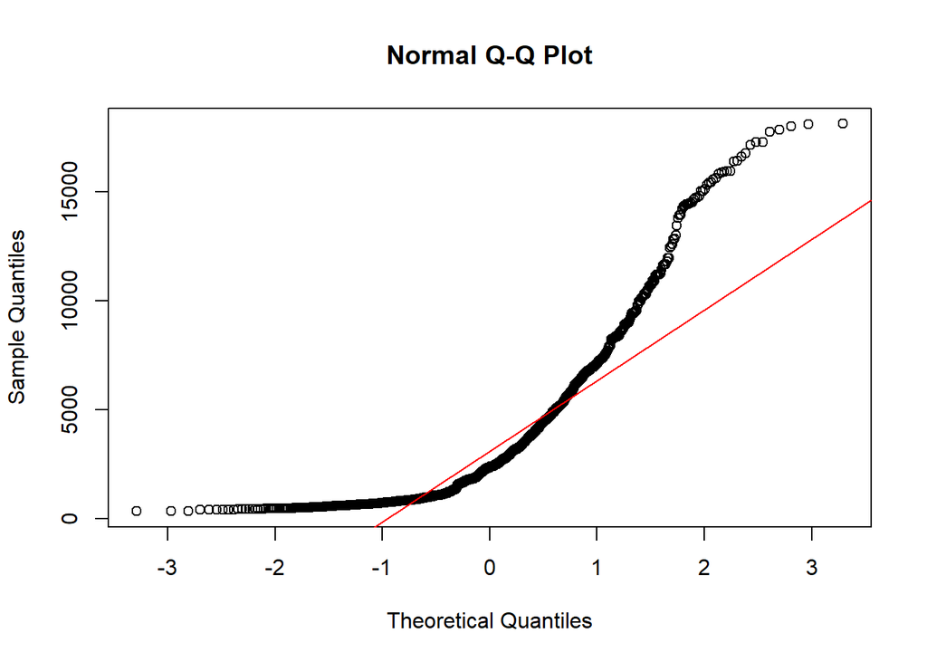

```r
qqnorm(dsmall$price)
qqline(dsmall$price, col="red")
```

The line I make red because it is a reference line. The closer the points are to following this line, the more “normal” the shape of the distribution is. Price has some pretty strong deviation away from that line. Below I have plotted what a normal distribution looks like as an example of a “perfect” fit.

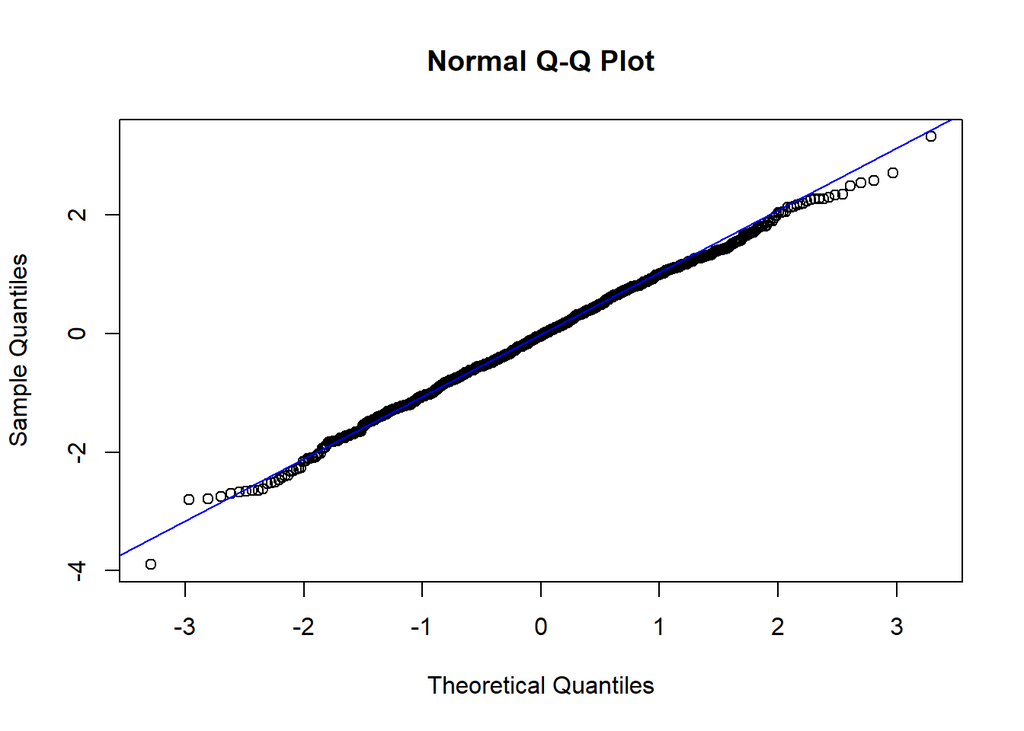

```r
z <- rnorm(1000)
qqnorm(z)
qqline(z, col="blue")
```

#### ggplot

qq (or qnorm) plots specifically plot the data against a theoretical distribution. That means in the `aes()` aestetic argument we don’t specify either x or y, but instead the `sample=` is the variable we want to plot.

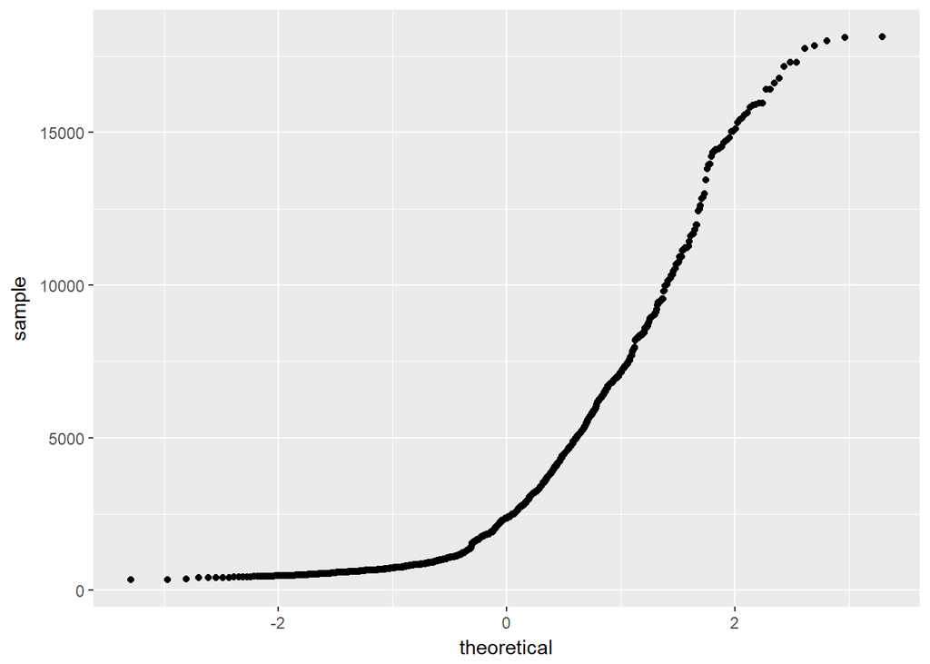

```r
ggplot(dsmall, aes(sample=price)) + stat_qq()
```

Additional references on making qqplots in ggplot: http://www.sthda.com/english/wiki/ggplot2-qq-plot-quantile-quantile-graph-quick-start-guide-r-software-and-data-visualization

# Bivariate (Two Variables)

## Categorical v. Categorical

### Two-way Tables

Cross-tabs, cross-tabulations and two-way tables (all the same thing, different names) can be created by using the `table()` function.

#### Frequency table

The frequency table is constructed using the `table()` function.

```r
table(dsmall$cut, dsmall$color)
```

```
##
##              D  E  F  G  H  I  J
##   Fair       4  5  4  3 10  1  0
##   Good      13  6 19 16 10 13  6
##   Very Good 30 60 37 50 26 18  5
##   Premium   39 42 40 55 46 40 15
##   Ideal     63 69 52 77 65 40 21
```

There are 4 Fair diamonds with color D, and 21 Ideal quality diamonds with color J.

#### Cell proportions

Wrapping `prop.table()` around a table gives you the **cell** proportions.

```r
prop.table(table(dsmall$cut, dsmall$color))
```

```
##
##                 D     E     F     G     H     I     J
##   Fair      0.004 0.005 0.004 0.003 0.010 0.001 0.000
##   Good      0.013 0.006 0.019 0.016 0.010 0.013 0.006
##   Very Good 0.030 0.060 0.037 0.050 0.026 0.018 0.005
##   Premium   0.039 0.042 0.040 0.055 0.046 0.040 0.015
##   Ideal     0.063 0.069 0.052 0.077 0.065 0.040 0.021
```

0.4% of all diamonds are D color and Fair cut, 2.1% are J color and Ideal cut.

#### Row proportions

To get the **row** proportions, you specify `margin=1`. The percentages now add up to 1 across the rows.

```r
round(prop.table(table(dsmall$cut, dsmall$color), margin=1),3)
```

```
##
##                 D     E     F     G     H     I     J
##   Fair      0.148 0.185 0.148 0.111 0.370 0.037 0.000
##   Good      0.157 0.072 0.229 0.193 0.120 0.157 0.072
##   Very Good 0.133 0.265 0.164 0.221 0.115 0.080 0.022
##   Premium   0.141 0.152 0.144 0.199 0.166 0.144 0.054
##   Ideal     0.163 0.178 0.134 0.199 0.168 0.103 0.054
```

14.8% of all Fair quality diamonds are color D. 5.4% of all Ideal quality diamonds have color J.

#### Column proportions

To get the **column** proportions, you specify `margin=2`. The percentages now add up to 1 down the columns.

```r
round(prop.table(table(dsmall$cut, dsmall$color), margin=2),3)
```

```
##
##                 D     E     F     G     H     I     J
##   Fair      0.027 0.027 0.026 0.015 0.064 0.009 0.000
##   Good      0.087 0.033 0.125 0.080 0.064 0.116 0.128
##   Very Good 0.201 0.330 0.243 0.249 0.166 0.161 0.106
##   Premium   0.262 0.231 0.263 0.274 0.293 0.357 0.319
##   Ideal     0.423 0.379 0.342 0.383 0.414 0.357 0.447
```

2.7% of all D color diamonds are of Fair quality. 44.7% of all J color diamonds are of Ideal quality.

### Grouped bar charts

To compare proprtions of one categorical variable within the same level of another, is to use grouped barcharts.

#### base

As before, the object to be plotted needs to be the result of a table.

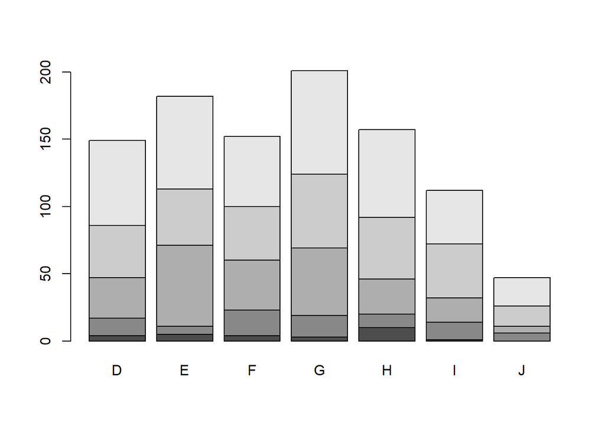

```r
cc <- table(dsmall$cut, dsmall$color)
barplot(cc)
```

Stacked bars can be difficult to interpret, and very difficult to compare values between groups. A side by side barchart is preferrable. The `beside=TRUE` is what controls the placement of the bars.

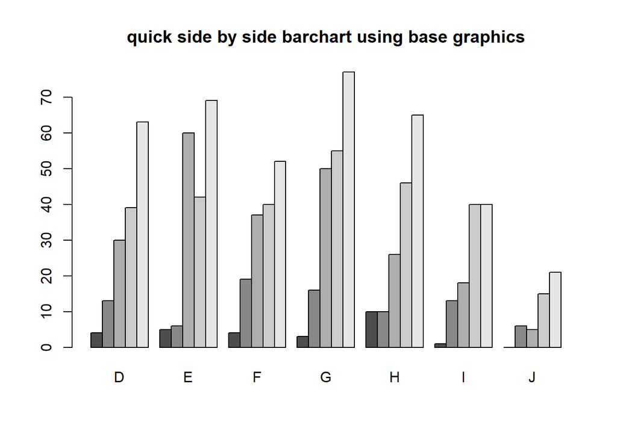

```r
barplot(cc, main="quick side by side barchart using base graphics", beside=TRUE)
```

Great, but what do the colors represent? We need to add a legend. And i’m going to customize the colors.

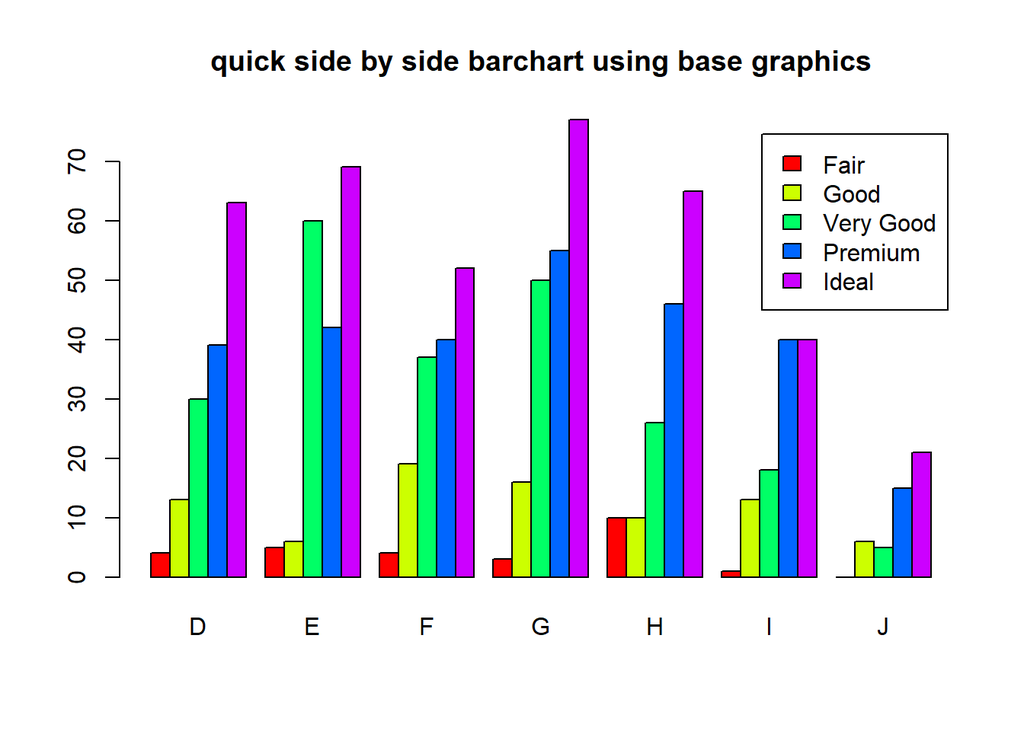

```r
barplot(cc, main="quick side by side barchart using base graphics", beside=TRUE,
        col=rainbow(5), legend=rownames(cc))
```

For more than 2 colors I do not recommend choosing the colors yourself. I know little about color theory so I use the built-in color palettes. Here is a [great cheatsheet](https://www.nceas.ucsb.edu/~frazier/RSpatialGuides/colorPaletteCheatsheet.pdf) about using color palettes.